# Praktikum 4

Raihana Asma Amani_G1401221039

2024-09-16

##Nomor 1 #Membangkitkan model MA(2) dengan 𝜃1 = 0.4 dan 𝜃2 = 0.6 sebanyak 300 data (Manual dan dengan arima.sim)

```r
set.seed(3939)
n <- 300
theta1 <- 0.4
theta2 <- 0.6
e <- rnorm(n)  # noise
Y <- numeric(n)

for (t in 3:n) {
  Y[t] <- e[t] + theta1 * e[t-1] + theta2 * e[t-2]
}
Y <- ts(Y)# rubah ke time series
Y
```

```
## Time Series:
## Start = 1
## End = 300
## Frequency = 1
##   [1]  0.0000000000  0.0000000000 -2.4761618107 -1.6299718374  0.0425674861
##   [6] -1.2204125700  0.2361554819 -1.0566355322  0.4240382969 -0.2617509503
##  [11] -0.0007220112 -1.1120652986 -1.4394967746 -1.9395941848 -0.6162162256
##  [16] -1.2110984023  0.9380400797 -0.8264155069  0.0577055384 -0.5051152512
##  [21]  0.3374221412  1.1988810202  1.0095650835 -0.0222337740  0.3993202955
##  [26] -0.3868045022 -0.1944445231 -1.3375710879  0.6942720663  0.2740890919
##  [31]  0.2910583912 -1.9621840365 -2.4572367208 -1.4197256433 -2.0972903671
##  [36] -0.3650906053  0.8373784390  1.3592791462  2.0818912593  0.5648833058
##  [41]  1.2253830610 -1.2046003702 -0.7130075533 -2.4872059260 -1.0340148783
##  [46]  1.4161243590  2.5042556981  2.9453687919  2.8357834193  1.1740885227
##  [51] -0.3296357783  1.6032008827 -0.6762721591  2.3093192408  0.0463707348
```

[output cut: 49 more lines]

#Menggunakan Arima.sim

```r
set.seed(3939)
Y_arima <- arima.sim(model = list(ma = c(0.4, 0.6)), n = 300)
Y_arima
```

```
## Time Series:
## Start = 1
## End = 300
## Frequency = 1
##   [1] -2.4761618107 -1.6299718374  0.0425674861 -1.2204125700  0.2361554819
##   [6] -1.0566355322  0.4240382969 -0.2617509503 -0.0007220112 -1.1120652986
##  [11] -1.4394967746 -1.9395941848 -0.6162162256 -1.2110984023  0.9380400797
##  [16] -0.8264155069  0.0577055384 -0.5051152512  0.3374221412  1.1988810202
##  [21]  1.0095650835 -0.0222337740  0.3993202955 -0.3868045022 -0.1944445231
##  [26] -1.3375710879  0.6942720663  0.2740890919  0.2910583912 -1.9621840365
##  [31] -2.4572367208 -1.4197256433 -2.0972903671 -0.3650906053  0.8373784390
##  [36]  1.3592791462  2.0818912593  0.5648833058  1.2253830610 -1.2046003702
##  [41] -0.7130075533 -2.4872059260 -1.0340148783  1.4161243590  2.5042556981
##  [46]  2.9453687919  2.8357834193  1.1740885227 -0.3296357783  1.6032008827
##  [51] -0.6762721591  2.3093192408  0.0463707348  1.8227686207 -0.0837098827
```

[output cut: 49 more lines]

#Buat plot time series, plot ACF, plot PACF dan plot EACF. Idenifikasi apakah data tersebut stasioner

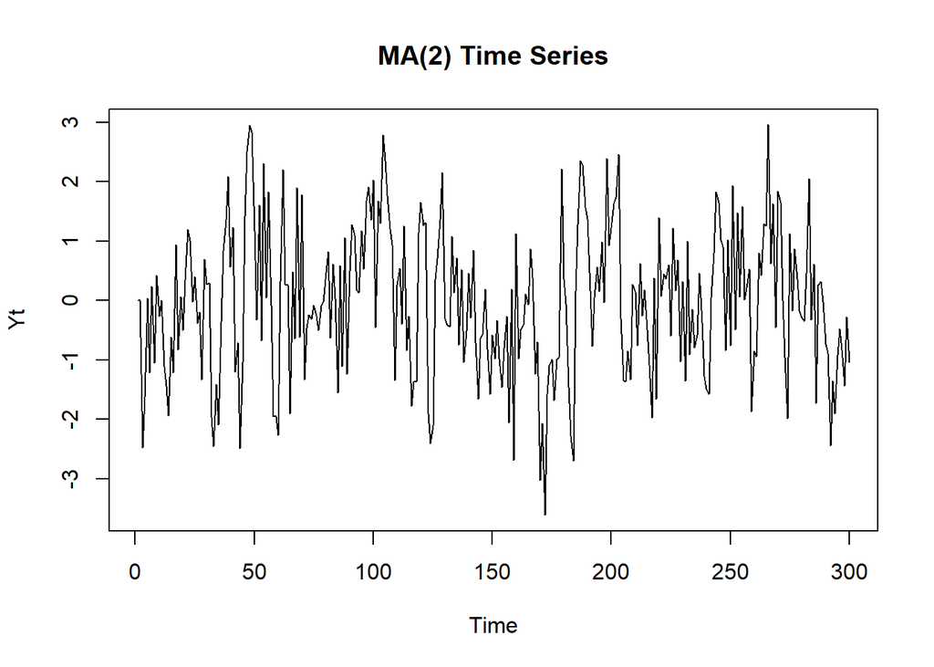

```r
# Plot Time Series
plot(Y, main = "MA(2) Time Series", ylab = "Yt", xlab = "Time")
```

Berdasarkan plot time series, terlihat bahwa data MA(2) yang dibangkitkan stasioner dalam rataan

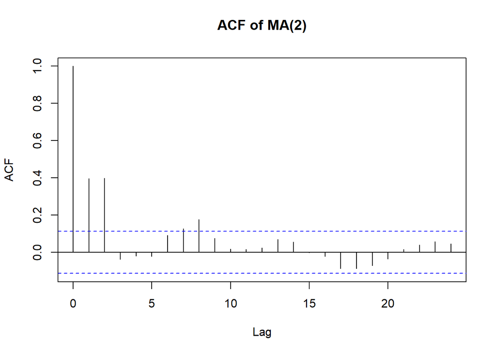

```r
# Plot ACF
acf(Y, main = "ACF of MA(2)")
```

Berdasarkan plot AFC tersebut, terlihat bahwa plot ACF *cuts off* di lag kedua

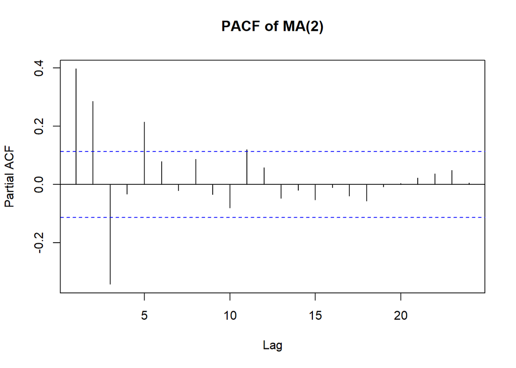

```r
# Plot PACF
pacf(Y, main = "PACF of MA(2)")
```

Berdasarkan plot PACF tersebut, terlihat bahwa plot PACF cenderung *tails off* dan membentuk gelombang sinus

```r
# Plot EACF (gunakan paket TSA)
library(TSA)
eacf(Y)
```

```
## AR/MA
##   0 1 2 3 4 5 6 7 8 9 10 11 12 13
## 0 x x o o o o x x o o o  o  o  o
## 1 x x x o o o o x o o o  o  o  o
## 2 x x x o o o o x o o o  o  o  o
## 3 o x o o x o o x o o o  o  o  o
## 4 x x x o x x o x o o o  o  o  o
## 5 x x x o x x o x o o o  o  o  o
## 6 x o x x o x x x o o o  o  o  o
## 7 x x x o o o x x o o o  o  o  o
```

Berdasarkan pola segitiga nol pada plot EACF, terlihat bahwa segitiga nol berada pada ordo AR(0) dan ordo MA(2)

#Buat Scatterplot antara 𝑌𝑡 dengan 𝑌𝑡−1, 𝑌𝑡 dengan 𝑌𝑡−2, dan 𝑌𝑡 dengan 𝑌𝑡−3

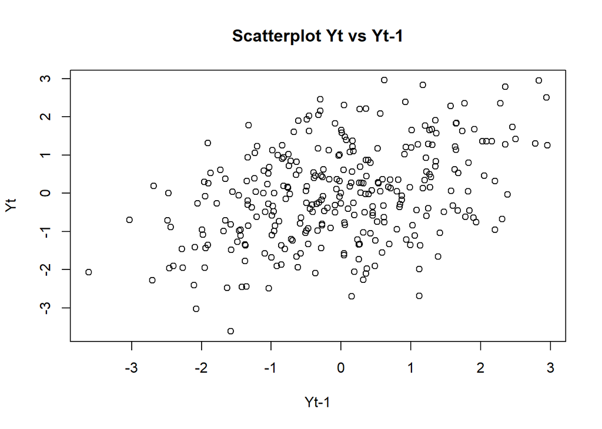

```r
# Scatterplot Yt dengan Yt-1
plot(Y[2:300], Y[1:299], main = "Scatterplot Yt vs Yt-1", xlab = "Yt-1", ylab = "Yt")
```

Berdasarkan scatterplot tersebut, terlihat bahwa terdapat hubungan positif antara $Y_t$ dengan $Y_{t-1}$. Hal ini sesuai dengan teori yang ada

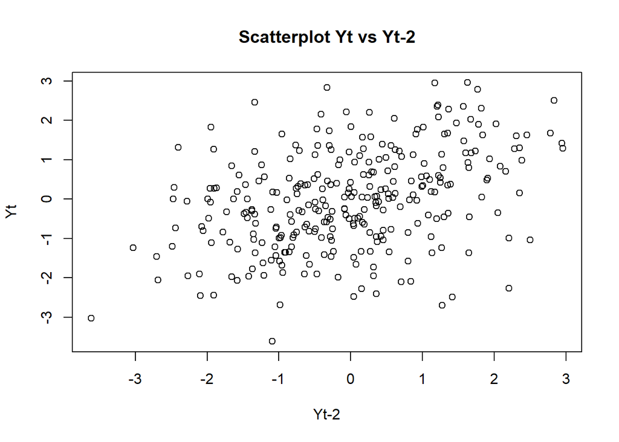

```r
# Scatterplot Yt dengan Yt-2
plot(Y[3:300], Y[1:298], main = "Scatterplot Yt vs Yt-2", xlab = "Yt-2", ylab = "Yt")
```

Berdasarkan scatterplot tersebut, terlihat bahwa terdapat hubungan positif antara $Y_t$ dengan $Y_{t-2}$. Hal ini sesuai dengan teori yang ada

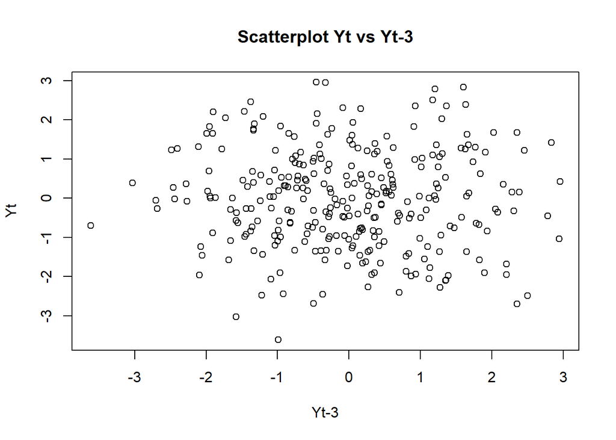

```r
# Scatterplot Yt dengan Yt-3
plot(Y[4:300], Y[1:297], main = "Scatterplot Yt vs Yt-3", xlab = "Yt-3", ylab = "Yt")
```

```r
#Autokorelasi Teoritis
rho1 <- theta1 / (1 + theta1^2 + theta2^2)
rho2 <- theta2 / (1 + theta1^2 + theta2^2)
rho1  # Lag 1 autokorelasi
```

```
## [1] 0.2631579
```

```r
rho2  # Lag 2 autokorelasi
```

```
## [1] 0.3947368
```

##Nomor 2 #Membangkitkan model AR(2) dengan 𝜙1 = 0.5 dan 𝜙2 = 0.2 sebanyak 300 data (Manual dan dengan arima.sim)

```r
set.seed(3939)
n <- 300
phi1 <- 0.5
phi2 <- 0.2
e <- rnorm(n)  # noise
Y <- numeric(n)

for (t in 3:n) {
  Y[t] <- phi1 * Y[t-1] + phi2 * Y[t-2] + e[t]
}
Y <- ts(Y)  # rubah ke time series
Y
```

```
## Time Series:
## Start = 1
## End = 300
## Frequency = 1
##   [1]  0.000000000  0.000000000 -1.115857212 -0.654253943  0.200313534
##   [6] -1.493556169 -0.335782206 -0.793893849 -0.131708367 -0.422966996
##  [11] -0.358650565 -1.208653397 -1.665164464 -2.051423206 -0.990652012
##  [16] -1.677679866 -0.010958058 -1.114593889 -0.807958829 -0.568478002
##  [21]  0.017305462  0.873531545  0.780480445 -0.180533323  0.559189517
##  [26]  0.106627469 -0.270564689 -1.195125033  0.736493681  0.496744181
##  [31] -0.293181202 -1.954398398 -2.316898290 -1.312335348 -2.542997379
##  [36] -1.471872432  0.422075445  0.572041931  1.190209154  0.553259812
##  [41]  1.310692199 -0.663258603 -0.688408026 -1.858940795 -1.176982558
##  [46]  1.329028180  2.083548562  2.217591745  3.004625683  1.982264577
##  [51]  0.360376233  2.650654359  0.630533651  2.217056452  1.192463454
```

[output cut: 49 more lines]

#Menggunakan Arima.sim

```r
set.seed(3939)
Y_arima <- arima.sim(model = list(ar = c(0.5, 0.2)), n = 300)
Y_arima
```

```
## Time Series:
## Start = 1
## End = 300
## Frequency = 1
##   [1]  0.103733751 -0.272770707 -1.196806785  0.735211601  0.495766791
##   [6] -0.293926313 -1.954966432 -2.317331329 -1.312665474 -2.543249050
##  [11] -1.472064292  0.421929180  0.571930427  1.190124149  0.553195009
##  [16]  1.310642796 -0.663296265 -0.688436738 -1.858962683 -1.176999244
##  [21]  1.329015459  2.083538865  2.217584352  3.004620047  1.982260281
##  [26]  0.360372958  2.650651862  0.630531748  2.217055001  1.192462348
##  [31]  2.056284143  0.801570772 -1.559790162 -1.344745203 -1.539364964
##  [36] -0.062379573  1.810654419 -0.284235463 -0.337528906 -1.197277850
##  [41]  0.541994284 -0.510275163  1.242978835 -0.324766255  1.375735017
##  [46] -0.713101338 -0.791980035  0.306357454 -0.235717763 -0.555265298
##  [51] -0.244749185 -0.464624641 -0.323503546 -0.119262562  0.196581401
```

[output cut: 49 more lines]

#Buat plot time series, plot ACF, plot PACF dan plot EACF. Idenifikasi apakah data tersebut stasioner

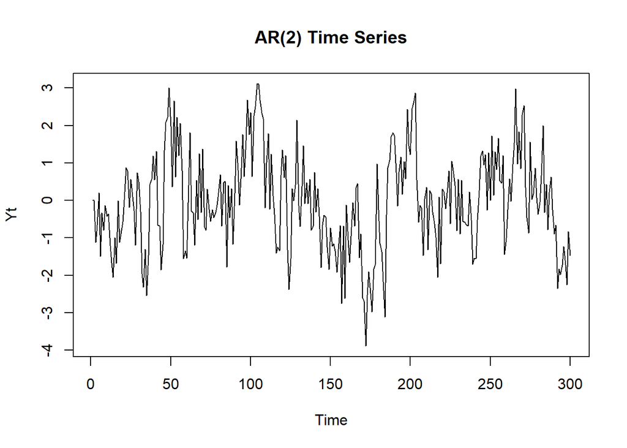

```r
# Plot Time Series
plot(Y, main = "AR(2) Time Series", ylab = "Yt", xlab = "Time")
```

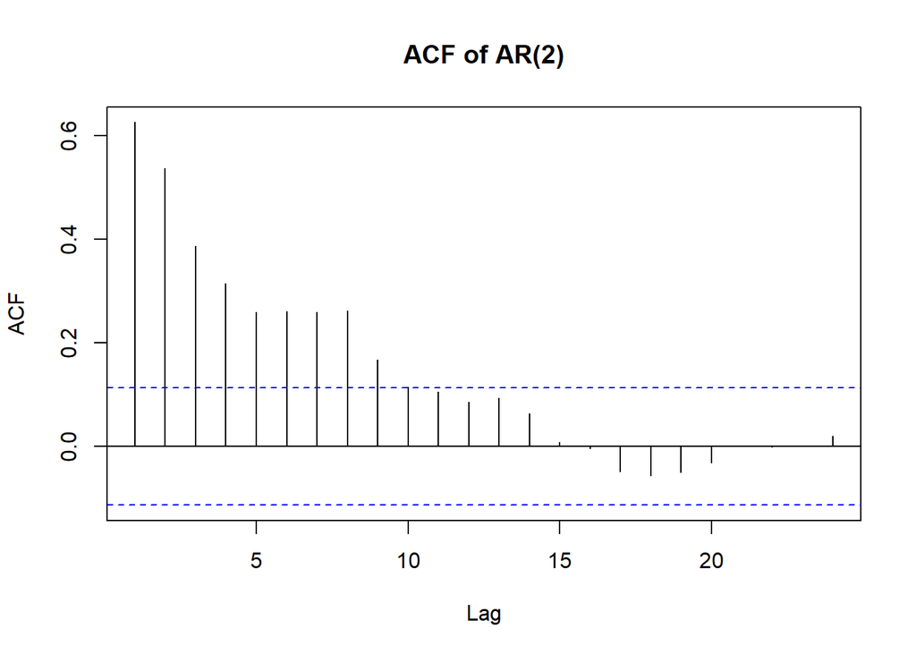

```r
# Plot ACF
acf(Y, main = "ACF of AR(2)")
```

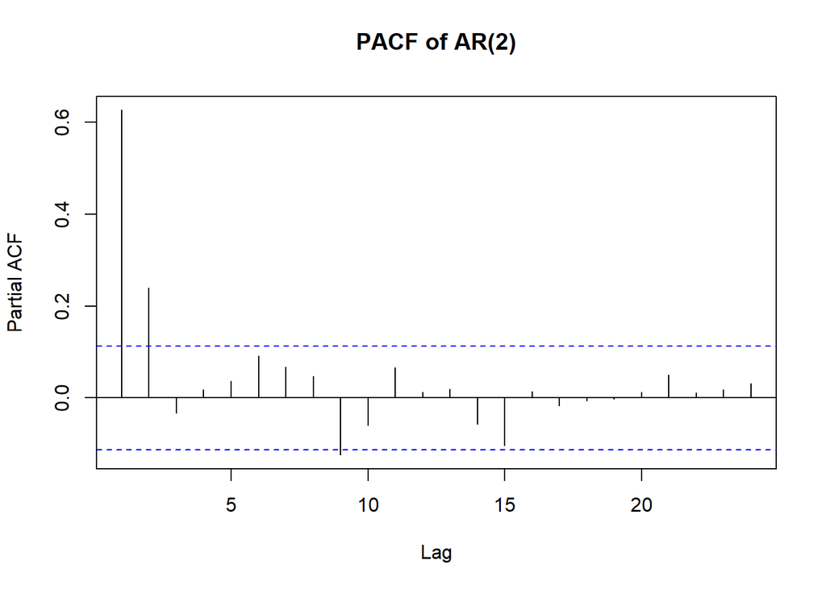

```r
# Plot PACF
pacf(Y, main = "PACF of AR(2)")
```

```r
# Plot EACF (gunakan paket TSA)
library(TSA)
eacf(Y)
```

```
## AR/MA
##   0 1 2 3 4 5 6 7 8 9 10 11 12 13
## 0 x x x x x x x x x o o  o  o  o
## 1 x x o o o o o x o o o  o  o  o
## 2 o o o o o o o x o o o  o  o  o
## 3 x o o o o o o x o x o  o  o  o
## 4 x o o o o o o x o o o  o  o  o
## 5 x o x o o o o o o o o  o  o  o
## 6 x o x o o x o x o o o  o  o  o
## 7 x o x x o x o o o o o  o  o  o
```

Berdasarkan pola segitiga nol pada plot EACF, terlihat bahwa segitiga nol berada pada ordo AR(2) dan ordo MA(0) #Buat scatterplot antara 𝑌𝑡 dengan 𝑌𝑡−1, 𝑌𝑡 dengan 𝑌𝑡−2 serta 𝑌𝑡dengan 𝑌𝑡−3

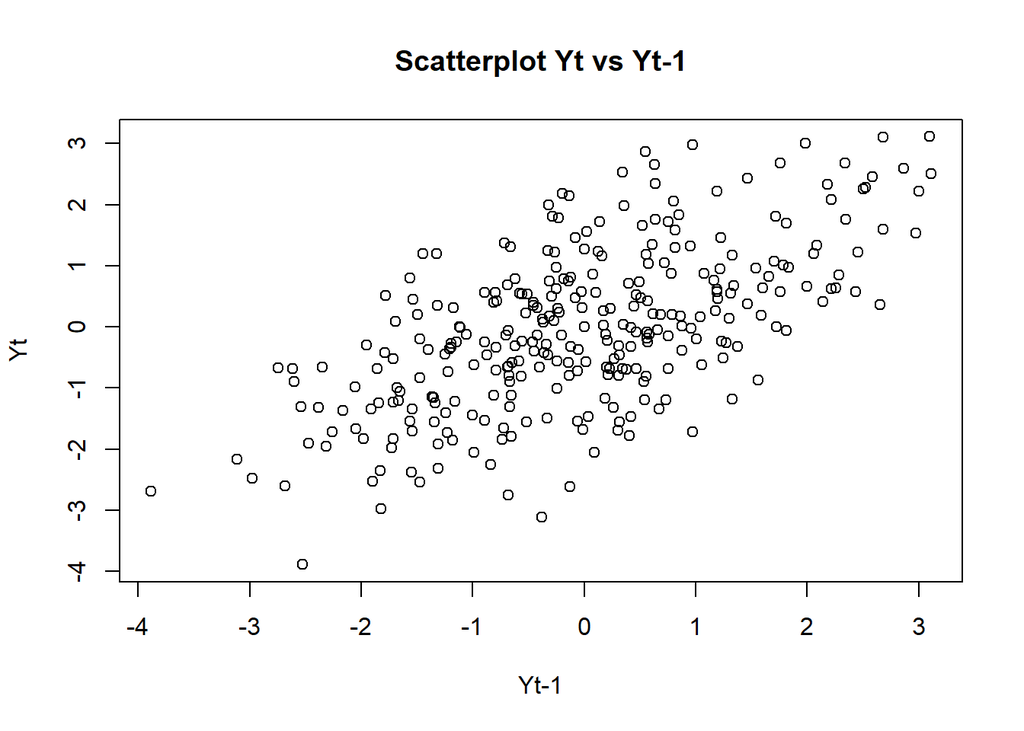

```r
# Scatterplot Yt dengan Yt-1
plot(Y[2:300], Y[1:299], main = "Scatterplot Yt vs Yt-1", xlab = "Yt-1", ylab = "Yt")
```

Berdasarkan scatterplot tersebut, terlihat bahwa terdapat hubungan positif antara $Y_t$ dengan $Y_{t-1}$. Hal ini sesuai dengan teori yang ada

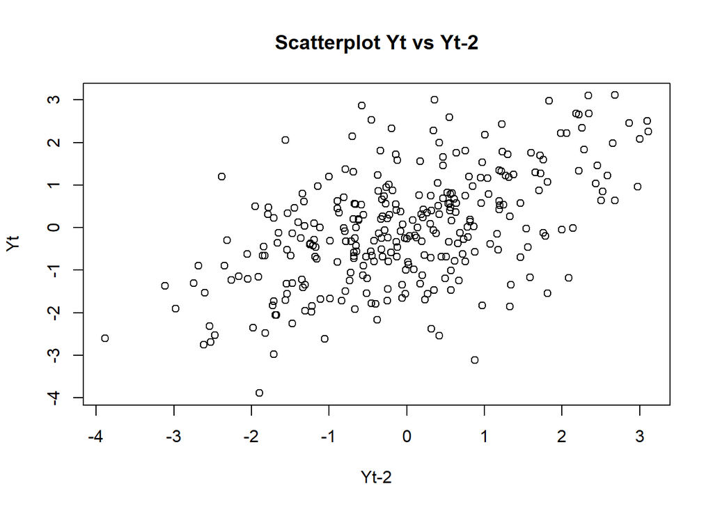

```r
# Scatterplot Yt dengan Yt-2
plot(Y[3:300], Y[1:298], main = "Scatterplot Yt vs Yt-2", xlab = "Yt-2", ylab = "Yt")
```

Berdasarkan scatterplot tersebut, terlihat bahwa terdapat hubungan positif antara $Y_t$ dengan $Y_{t-2}$. Hal ini sesuai dengan teori yang ada

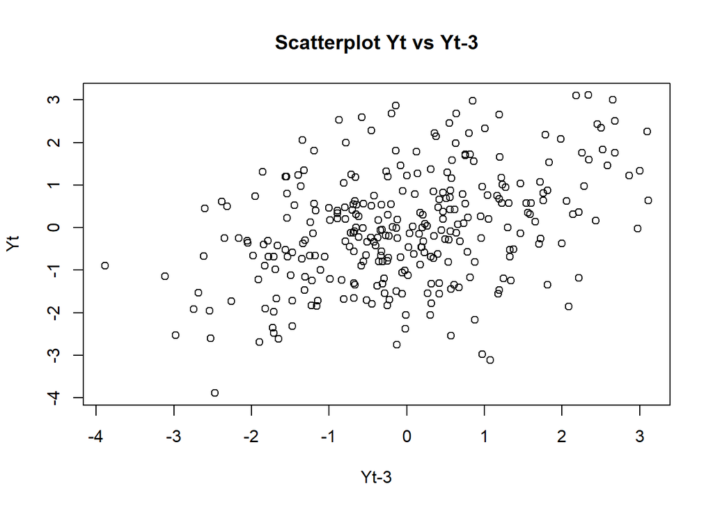

```r
# Scatterplot Yt dengan Yt-3
plot(Y[4:300], Y[1:297], main = "Scatterplot Yt vs Yt-3", xlab = "Yt-3", ylab = "Yt")
```

```r
# Autokorelasi Teoritis menggunakan persamaan Yule-Walker
phi1 <- 0.5
phi2 <- 0.2

# Lag 1 dan Lag 2
rho1 <- phi1 / (1 - phi2)
rho2 <- (phi1 * rho1 + phi2) / (1 - phi2)
rho1  # Lag 1 autokorelasi teoritis
```

```
## [1] 0.625
```

```r
rho2  # Lag 2 autokorelasi teoritis
```

```
## [1] 0.640625
```

##Nomor 3 #Membangkitkan model ARMA(2,2) dengan 𝜃1 = 0.4, 𝜃2 = 0.6 ,𝜙1 = 0.5 dan 𝜙2 = 0.2 sebanyak 300 data (Manual dan arima.sim)

```r
set.seed(3939)
n <- 300
phi1 <- 0.5
phi2 <- 0.2
theta1 <- 0.4
theta2 <- 0.6
e <- rnorm(n)  # noise
Y <- numeric(n)

for (t in 3:n) {
  Y[t] <- phi1 * Y[t-1] + phi2 * Y[t-2] + e[t] - theta1 * e[t-1] - theta2 * e[t-2]
}
Y <- ts(Y)  # convert to time series
Y
```

```
## Time Series:
## Start = 1
## End = 300
## Frequency = 1
##   [1]  0.000000000  0.000000000  0.244447386  1.559544857  2.287318316
##   [6] -0.249743595  0.838302727  0.771255152  0.794039822  0.416353807
##  [11]  0.126056092 -0.631105326 -0.829059974 -0.555377456  0.908900470
##  [16]  0.010334708  1.300931923 -0.068209363 -0.328564382  0.444031567
##  [21]  0.745153225  1.219650735  0.429798089 -1.009896744  0.168411129
##  [26] -0.004690532 -0.645651171 -1.148528968  1.378671486  0.920585552
##  [31] -0.932735376 -2.134379808 -1.358625959  0.787523656 -0.627573092
##  [36]  0.332995446  2.536826939  1.286490802  0.708265728 -0.265958583
##  [41]  0.375331717 -1.519438817 -1.209479841 -1.185591881 -0.020338140
##  [46]  2.915203431  2.258140357  0.586765728  0.867467712 -0.550134747
##  [51] -2.235300437  1.317148604 -0.645951176  0.374452401 -0.072677774
```

[output cut: 49 more lines]

#Menggunakan Arima.sim

```r
set.seed(3939)
Y_arima <- arima.sim(model = list(ar = c(0.5, 0.2), ma = c(0.4, 0.6)), n = 300)
Y_arima
```

```
## Time Series:
## Start = 1
## End = 300
## Frequency = 1
##   [1] -1.241721098  0.094315876  0.072902810  0.346372972 -1.774416989
##   [6] -3.275170621 -3.412194351 -4.458421667 -3.276740309 -1.692676049
##  [11] -0.142406940  1.672152579  1.372478208  2.246052681  0.192921612
##  [16] -0.167336211 -2.532289709 -2.333626975 -0.257147070  1.908956768
##  [21]  3.848417762  5.141783654  4.514663902  2.956052903  3.984160115
##  [26]  1.907018479  4.059660503  2.457604682  3.863503062  2.339562585
##  [31] -0.005390798 -1.487718370 -3.013136811 -1.484972428  0.862083804
##  [36]  0.402598707  0.635169672 -1.502830605 -0.139434134 -1.011844110
##  [41]  1.364065378 -0.133739790  1.991615838 -0.357667068 -0.251779548
##  [46] -0.438295353 -0.588362795 -0.465737925 -0.608285958 -0.895683490
##  [51] -0.656202911 -0.527438762 -0.045225750  0.694194452 -0.296527805
```

[output cut: 49 more lines]

#Buat plot time series, plot ACF, plot PACF dan plot EACF. Idenifikasi apakah data tersebut stasioner

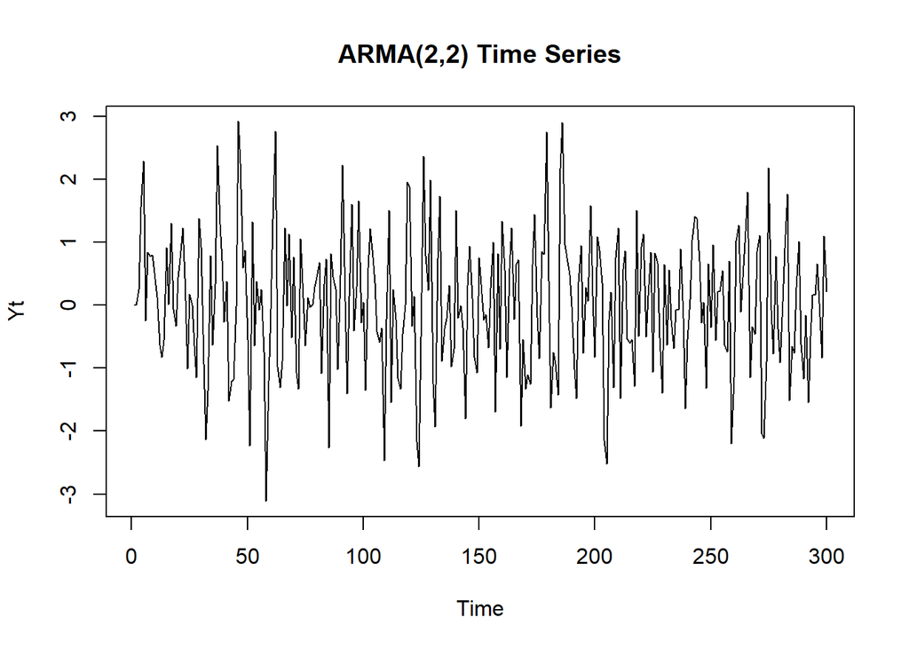

```r
# Plot Time Series
plot(Y, main = "ARMA(2,2) Time Series", ylab = "Yt", xlab = "Time")
```

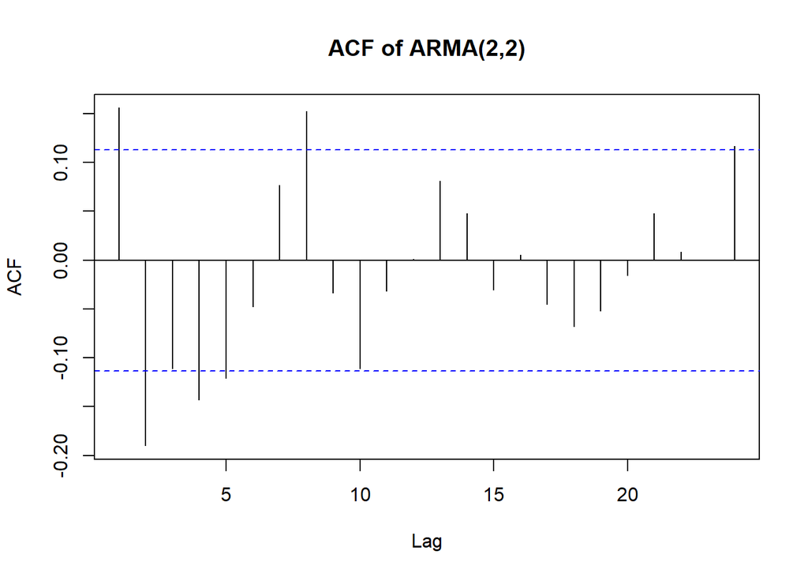

```r
# Plot ACF
acf(Y, main = "ACF of ARMA(2,2)")
```

Berdasarkan plot ACF tersebut, terlihat bahwa model ARMA(2,2) hasil simulasi memiliki plot ACF yang *tails off*, sesuai dengan teori yang ada

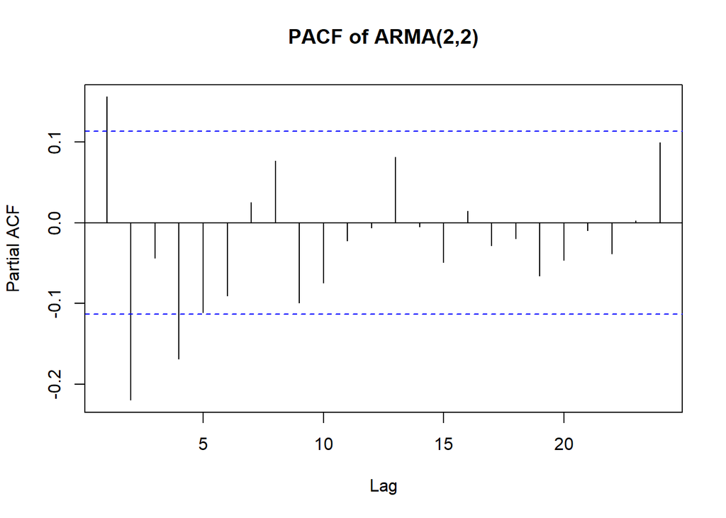

```r
# Plot PACF
pacf(Y, main = "PACF of ARMA(2,2)")
```

```r
# Plot EACF (gunakan paket TSA)
library(TSA)
eacf(Y)
```

```
## AR/MA
##   0 1 2 3 4 5 6 7 8 9 10 11 12 13
## 0 x x o x x o o x o o o  o  o  o
## 1 x x o o o o o x o o o  o  o  o
## 2 x x o o o o o o o o o  o  o  o
## 3 x x o o o o o o o o o  o  o  o
## 4 x o x o o o o o o o o  o  o  o
## 5 x o x o o o o o o o o  o  o  o
## 6 x x x o x o o o o o o  o  o  o
## 7 x x x o x o o o o o o  o  o  o
```

```r
# Identifikasi Stasioneritas
library(tseries)
adf.test(Y)
```

```
##
##  Augmented Dickey-Fuller Test
##
## data:  Y
## Dickey-Fuller = -8.4767, Lag order = 6, p-value = 0.01
## alternative hypothesis: stationary
```

Berdasarkan pola segitiga nol pada plot EACF, terlihat bahwa segitiga nol berada pada ordo AR(2) dan ordo MA(2) #Buat scatterplot antara 𝑌𝑡 dengan 𝑌𝑡−1, 𝑌𝑡 dengan 𝑌𝑡−2 serta 𝑌𝑡dengan 𝑌𝑡−3

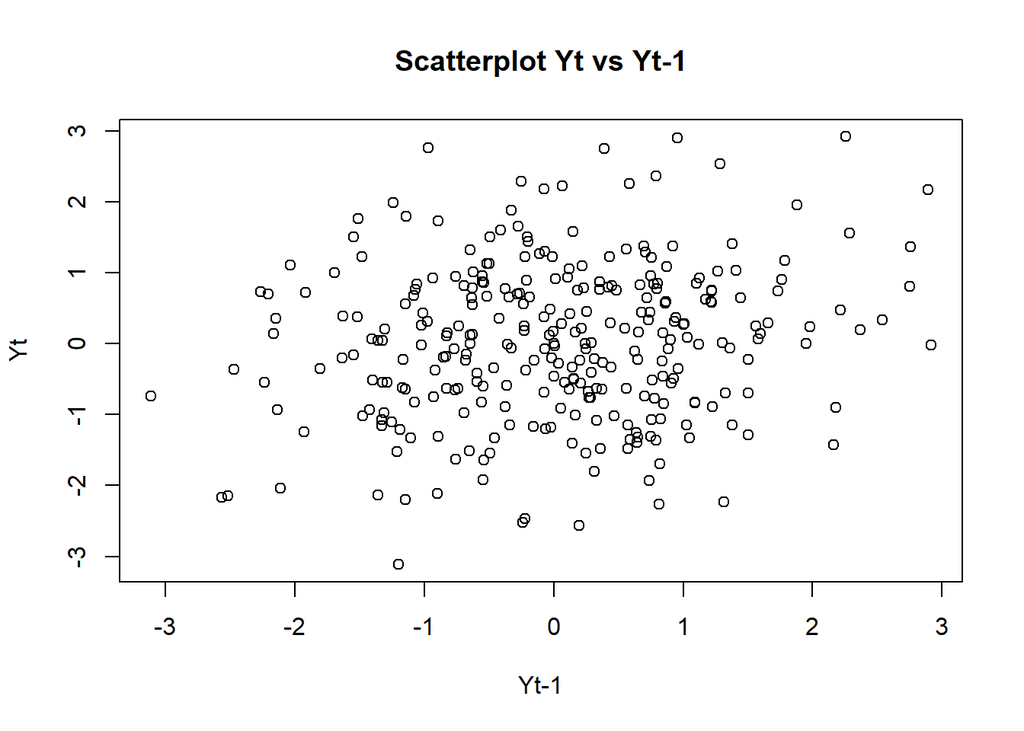

```r
# Scatterplot Yt dengan Yt-1
plot(Y[2:300], Y[1:299], main = "Scatterplot Yt vs Yt-1", xlab = "Yt-1", ylab = "Yt")
```

Berdasarkan scatterplot tersebut, terlihat bahwa terdapat hubungan positif antara $Y_t$ dengan $Y_{t-1}$. Hal ini sesuai dengan teori yang ada

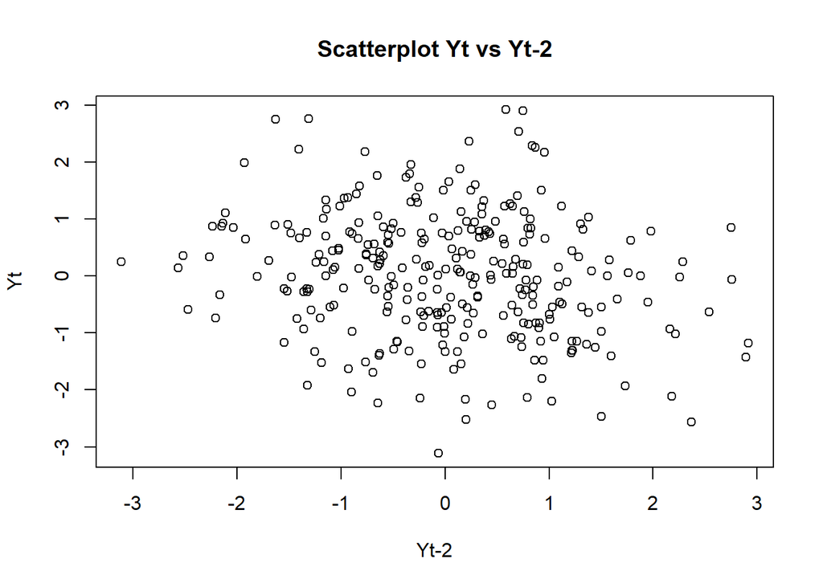

```r
# Scatterplot Yt dengan Yt-2
plot(Y[3:300], Y[1:298], main = "Scatterplot Yt vs Yt-2", xlab = "Yt-2", ylab = "Yt")
```

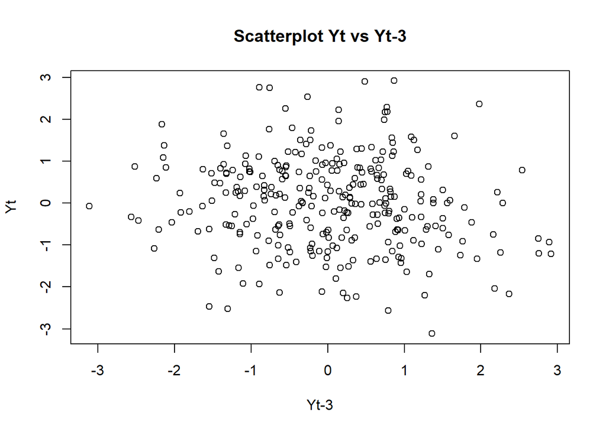

```r
# Scatterplot Yt dengan Yt-3
plot(Y[4:300], Y[1:297], main = "Scatterplot Yt vs Yt-3", xlab = "Yt-3", ylab = "Yt")
```

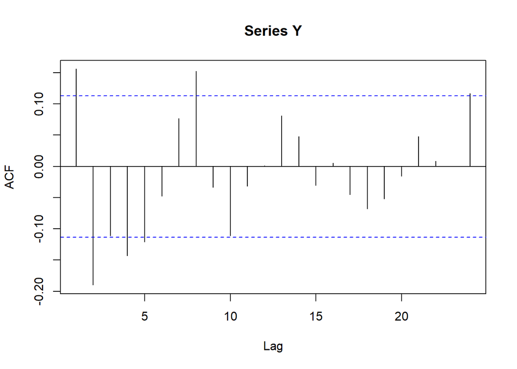

```r
acf(Y)
```

Berdasarkan plot ACF tersebut, terlihat bahwa model ARMA(2,2) hasil simulasi memiliki plot ACF yang *tails off*, sesuai dengan teori yang ada